# Simple deterministic discrete MSIR model

Amy Dighe

6 March 2018

## This is the first draft using *odin* to write a discrete-time deterministic MSIR model for MERS-CoV in camels

1. Individuals are born into **‘M’** where they are protected by maternal antibodies
   - Currently all camels are born into this, which will need to be changed to be a function of the number of adult camels that have been exposed to MERS-CoV, with an option for camels to be born to susceptible mothers, and be immediately susceptible themselves
2. Individuals in **‘M’** move through age categories (width 30 days), until they become susceptible **‘S’** at ~6 months old
3. **‘S’** individuals may become infectious **‘I’**, and **‘I’** individuals may recover at a rate inversely proportional to the estimated duration of infection and become **‘R’**.
   - Currently individuals in **‘R’** are modelled to be completely immune, in reality there is some incidences of recurring infection so this will be made more nuanced at some point

At the moment there are multiple flows out of compartments which could in theory result in negative numbers of individuals in each compartment. This will be adapted alongside development of the stochastic version of the model

Firstly load the model to run using odin (I’ve sent this script to you)

```r
sir_model <- odin::odin("ageing_complete_det.R", verbose = FALSE)
```

Within this script is the following model

```r
## A simple deterministic discrete time model with ageing

N_age <- 6 ## number of age categories between 0 and 6 months
N_age2 <- 6 ## number of age categories between 6 months and 2 years

## the proportion of individuals in each age category
## 6m-9m, 9m-12m, 12m-15m, 15m-18m, 18m-21, 21-24m, 2yr+
den_age2[1:6]<- 0.1
den_age2[7] <- 0.4

## equations for transitions between compartments
## M = individuals protected by maternal antibodies (<6 months of age)
## S = susceptible individuals
## I = infectious individuals
## R = recovered individuals

update(M[1]) <- if((tt %% 30) == 0) M[1] - M[1] + alpha * N_0 - mu * M[1] else M[1] + alpha * N_0 - mu * M[1]
update(M[2:N_age]) <- if(tt %% 30 == 0) M[i] - M[i] + M[i-1] - mu * M[i] else M[i] - mu * M[i]

update(S[N_age2 + 1]) <- if((tt %% 91) == 0) S[N_age2 + 1] + S[N_age2] else S[N_age2 + 1] - beta * S[N_age2 + 1] * sum(I[1:(N_age2 + 1)]) / N - mu * S[N_age2 + 1]
update(S[2:N_age2]) <- if((tt %% 91) == 0) S[i] - S[i] + S[i - 1] else S[i] - beta * S[i] * sum(I[1:(N_age2+1)]) / N - mu * S[i]
update(S[1]) <- if((tt %% 91) == 0) S[1] - S[1] else if ((tt %% 30) == 0) S[1] + M[N_age] else S[1] - ((beta * S[1] * sum(I[1:(N_age2+1)])) / N) - mu * S[1]

update(I[1]) <- if ((tt %% 91) == 0) 0 else if(tt == ttt) imported_cases + I[1] + beta * S[1] * sum(I[1:(N_age2+1)]) / N - gamma * I[1] - mu * I[1] else I[1] + beta * S[1] * sum(I[1:(N_age2+1)]) / N - gamma * I[1] - mu * I[1]
update(I[2:N_age2]) <- if((tt %% 91) == 0) 0 + I[i - 1] else I[i] + beta * S[i] * sum(I[1:(N_age2+1)]) / N - gamma * I[i] - mu * I[i]
update(I[N_age2 + 1]) <- if(tt %% 91 == 0) I[N_age2 + 1] + I[N_age2] else I[N_age2 + 1] + beta * S[N_age2 + 1] * sum(I[1:(N_age2+1)]) / N - gamma * I[N_age2 + 1] - mu * I[N_age2 + 1]

update(R[1]) <- if((tt %% 91) == 0) 0 else R[1] + gamma * I[1] - mu * R[1]
update(R[2:N_age2]) <- if((tt %% 91) == 0) 0 + R[i - 1] else R[i] + gamma * I[i] - mu * R[i]
update(R[N_age2 + 1]) <- if(tt %% 91 == 0) R[N_age2 + 1] + R[N_age2] else R[N_age2 + 1]+ gamma * I[N_age2 + 1] - mu * R[N_age2 + 1]

update(tt) <- tt + 1 # used to count time, must start at one for %% conditioning to work


## record total population size

N <- (sum(M[1:N_age]) + sum(S[1:(N_age2+1)]) + sum(I[1:(N_age2+1)]) + sum(R[1:(N_age2+1)]))


## initial states

initial(M[1:N_age]) <- M_ini # will be user-defined
initial(S[1:(N_age2 + 1)]) <- S_ini[i] # will be user-defined
initial(I[1:(N_age2 + 1)]) <- I_ini # will be user-defined
initial(R[1:(N_age2 + 1)]) <- 0
initial(tt) <- 1

## initial population size for use in birthrate

N_0 <- sum(S_ini[1:7]) + I_ini*(N_age2 + 1)

M_ini <- user(0) # user-defined, default = 0
S_ini[1:7] <- 1000 * den_age2[i]
I_ini <- user(1) # user-defined, default = 1

## rates of transition

alpha <- user(0) # birth rate, user-defined, default = 0
beta <- user(0.3) # infection rate, user-defined, default =  0.3
mu <- user(0) # death rate, user-defined, default = 0
gamma <- user(0.05) # recovery rate, user-defined, default = 0.1

ttt <- user(1500) # time of importation of cases, user-defined, default day 1500
imported_cases <- user(0) # imported cases, user-defined, default = 0

## useful outputs

output(MM) <- sum(M[1:N_age]) # total number of individuals still protected by maternal immunity
output(SS) <- sum(S[1:(N_age2 + 1)]) # total number of susceptible individuals
output(II) <- sum(I[1:(N_age2 + 1)]) # total number of infectious individuals
output(RR) <- sum(R[1:(N_age2 + 1)]) # total number of recovered individuals (modelled to be immune)
output(N) <- N # total number of individuals

output(SJ) <- sum(S[1:N_age2]) # total number of susceptible juveniles
output(IJ) <- sum(I[1:N_age2]) # total number of infectious juveniles
output(RJ) <- sum(R[1:N_age2]) # total number of recovered juveniles (modelled to be immune)

output(SA) <- S[N_age2 + 1] # total number of susceptible adults
output(IA) <- I[N_age2 + 1] # total number of infectious adults
output(RA) <- R[N_age2 + 1] # total number of recovered adults (modelled to be immune)

## dim calls needed for arrays

dim(M) <- N_age
dim(S) <- 7
dim(I) <- 7
dim(R) <- 7
dim(S_ini) <- 7
dim(den_age2) <- 7
```

I run this model from a seperate script in which changes to scenarios (key parameters including an option for importing cases) can be made simply within a short amount of code

```r
#sir_model <- odin::odin("ageing_complete_det.R", verbose = FALSE)

alpha <- 0.001 ## input a value for birth rate (default = 0)
mu <- 0.001 ## input a value for death rate (default = 0)
ttt <- 2000 ## time for importation of cases
imported_cases <- 1 ## input a value for imported cases at time, ttt
time_period <- 2000 ## input the time period that you wish to run the model for

t <- seq(0:time_period)
x <- sir_model(mu = mu, alpha = alpha, imported_cases = imported_cases, ttt = ttt) ## include any updated paramters as arguments in the model function

mod_run <- x$run(t) ## run the model
```

Here are some basic time series plots showing the dynamics of this model

```r
sir_col <- c("aquamarine2", "#8c8cd9", "#cc0044", "black", "pink", "gold", "dimgrey")
```

## Figure 1.

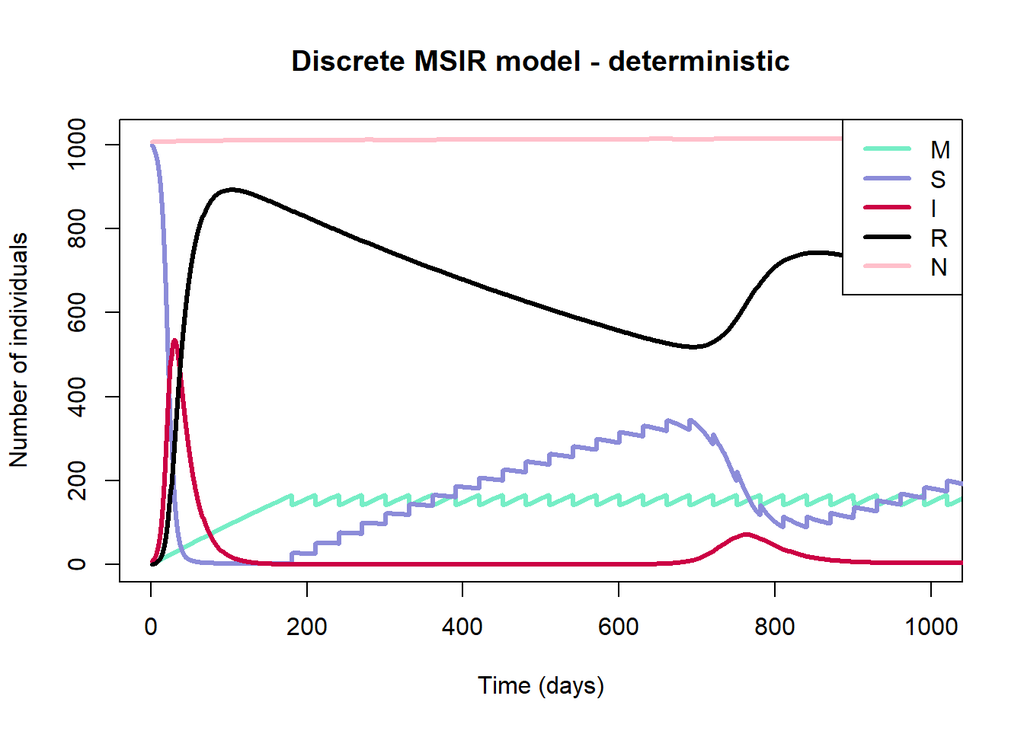

```r
matplot(x = mod_run[, 1], y = mod_run[, 30:34], xlab = "Time (days)", ylab = "Number of individuals",
        main = "Discrete MSIR model - deterministic", type = "l", col = sir_col,
        lwd = 3, lty = 1, xlim = c(0, 1000))
legend("topright", lwd = 3, col = sir_col, legend = c("M", "S", "I", "R", "N"))
```

## Figure 2.

This shows a bit more how the ageing is working (in the absence of infection, the S compartment is shown alone for clarity) - individuals born into M are being added into S1 every 30 days, and individuals are moving through the S compartments to an older age class every 91 days, with intermediate age class remaining almost constant size, except the final age class where adults accumulate, and decrease at death rate **mu**.

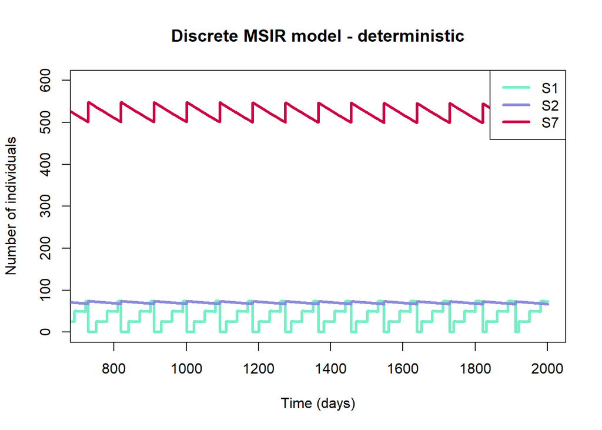

```r
alpha <- 0.001 ## input a value for birth rate (default = 0)
mu <- 0.001 ## input a value for death rate (default = 0)
ttt <- 2000 ## time for importation of cases
imported_cases <- 1 ## input a value for imported cases at time, ttt
time_period <- 2000 ## input the time period that you wish to run the model for
I_ini <- 0

t <- seq(0:time_period)
x <- sir_model(mu = mu, alpha = alpha, imported_cases = imported_cases, ttt = ttt, I_ini = I_ini) ## include any updated paramters as arguments in the model function

mod_run <- x$run(t) ## run the model



matplot(x = mod_run[, 1], y = mod_run[, c(3,4,9)], xlab = "Time (days)", ylab = "Number of individuals",
        main = "Discrete MSIR model - deterministic", type = "l", col = sir_col,
        lwd = 3, lty = 1, ylim = c(0,600), xlim = c(730, 2000))
legend("topright", lwd = 3, col = sir_col, legend = c("S1", "S2", "S7"))
```

## Next steps *alongside developing a stochastic version of this model*

1. Sort out what is going wrong with **mu**
2. Set up the model so it starts running from a demographic equilibrium so that we don’t have to wait years for births and deaths to equilibriate
3. Make births seasonal
4. Write the model equations so that there is a single outflow from the compartment and this is then seperated into destination compartments
5. Put in the infrastructure for **mu** to vary for different age compartments